# 36-315 Final Project

Minji Lee, Oliver Qin, Erik Ross, Juliette Wong

minjil, oqin, erross, jnwong

# Introduction

As current undergraduate students, we wanted to reflect on our college application process and learn about different colleges in the United States. There are many factors that one might consider when applying to colleges. Many colleges advertise their high endowments, geographic location, and nearby neighborhoods or local communities to entice students into looking into and eventually applying to them. In addition, some students are attracted to the low acceptance rate of universities, as it makes the school seem more elite, competitive, and selective. Other factors that may be of consideration for a student are whether they want to attend a large state university or a smaller private school, as well as what percent of students who enrolled actually graduate from the university. To get a better understanding of the different colleges in the United States, we want to see if these factors are related to one another, and if so, how.

## Data

Loading and Manipulation of our data set:

```r
admissions <- read_csv("admissions.csv")
admissions <- as.data.frame(admissions)
college_data <- admissions %>%
  dplyr::select(name = Name,
                applicants = `Applicants total`,
                admitted = `Admissions total`,
                endowment_GASB = `Endowment assets (year end) per FTE enrollment (GASB)`,
                endowment_FASB = `Endowment assets (year end) per FTE enrollment (FASB)`,
                grad_rate = `Graduation rate - Bachelor degree within 5 years, total`,
                urbanization = `Degree of urbanization (Urban-centric locale)`,
                region = `Geographic region`,
                control = `Control of institution`) %>%
  # Calculate Acceptance Rate
  mutate(acceptance_rate = admitted / applicants * 100) %>%
  # Create Endowment column
  mutate(endowment_GASB = replace(endowment_GASB, is.na(endowment_GASB), 0),
         endowment_FASB = replace(endowment_FASB, is.na(endowment_FASB), 0),
         endowment = endowment_GASB + endowment_FASB) %>%
  # Rename Geographic regions
  # I personally did this so the names are shorter / easier to read when plotting the marginal distribution
  mutate(region = fct_recode(factor(region),
                       "West" = "Far West AK CA HI NV OR WA",
                       "Mid East" = "Mid East DE DC MD NJ NY PA",
                       "Plains" = "Plains IA KS MN MO NE ND SD",
                       "Southeast" = "Southeast AL AR FL GA KY LA MS NC SC TN VA WV",
                       "US Service schools" = "US Service schools",
                       "Great Lakes" = "Great Lakes IL IN MI OH WI",
                        "New England" = "New England CT ME MA NH RI VT",
                       "Rocky Mountains" = "Rocky Mountains CO ID MT UT WY",
                       "Southwest" = "Southwest AZ NM OK TX"
                       )) %>%
  # Change Order of Urbanization
  mutate (urbanization = ordered(urbanization,
                                 levels = c("City: Large", "City: Midsize",
                                            "City: Small", "Suburb: Large",
                                            "Suburb: Midsize", "Suburb: Small",
                                            "Town: Fringe", "Town: Distant",
                                            "Town: Remote", "Rural: Fringe",
                                            "Rural: Distant", "Rural: Remote"
                                            ))) %>%
 # Make Urbanization less specific (just "City" instead of "City-small")
  mutate(urbanization_group = fct_recode(factor(urbanization),
                                "City" = "City: Large",
                                "City" = "City: Midsize",
                                "City" = "City: Small",
                                "Suburb" = "Suburb: Large",
                                "Suburb" = "Suburb: Midsize",
                                "Suburb" = "Suburb: Small",
                                "Town" = "Town: Distant",
                                "Town" = "Town: Fringe",
                                "Town" = "Town: Remote",
                                "Rural" = "Rural: Distant",
                                "Rural" = "Rural: Fringe",
                                "Rural" = "Rural: Remote")) %>%
  # Change order of urbanization_groups
  mutate(urbanization_group = ordered(urbanization_group,
                                      levels = c("City", "Suburb", "Town",
                                                 "Rural"))) %>%
  dplyr::select(name,acceptance_rate, grad_rate, endowment, urbanization,urbanization_group, region, control)

# Figure out which colleges were NA
college_na <- college_data %>%
  filter_all(any_vars(is.na(.) | . == 0))

# Filter out colleges with NA or 0
college_data <- college_data %>%
  drop_na() %>%
  filter(endowment != 0 & grad_rate != 0)
```

Additional data needed for later graphics:

```r
state_region <- data.frame(State = toupper(state.abb))
state_region <- state_region %>%
  mutate(region = case_when(# West
                            State == "AK" ~ "West",
                            State == "CA" ~ "West",
                            State == "HI" ~ "West",
                            State == "NV" ~ "West",
                            State == "OR" ~ "West",
                            State == "WA" ~ "West",
                            # Mid East
                            State == "DE" ~ "Mid East",
                            State == "DC" ~ "Mid East",
                            State == "MD" ~ "Mid East",
                            State == "NJ" ~ "Mid East",
                            State == "NY" ~ "Mid East",
                            State == "PA" ~ "Mid East",
                            # Plains
                            State == "IA" ~ "Plains",
                            State == "KS" ~ "Plains",
                            State == "MN" ~ "Plains",
                            State == "MO" ~ "Plains",
                            State == "NE" ~ "Plains",
                            State == "ND" ~ "Plains",
                            State == "SD" ~ "Plains",
                            # South East
                            State == "AL" ~ "Southeast",
                            State == "AR" ~ "Southeast",
                            State == "FL" ~ "Southeast",
                            State == "GA" ~ "Southeast",
                            State == "KY" ~ "Southeast",
                            State == "LA" ~ "Southeast",
                            State == "MS" ~ "Southeast",
                            State == "NC" ~ "Southeast",
                            State == "SC" ~ "Southeast",
                            State == "TN" ~ "Southeast",
                            State == "VA" ~ "Southeast",
                            State == "WV" ~ "Southeast",
                            # Great Lakes
                            State == "IL" ~ "Great Lakes",
                            State == "IN" ~ "Great Lakes",
                            State == "MI" ~ "Great Lakes",
                            State == "OH" ~ "Great Lakes",
                            State == "WI" ~ "Great Lakes",
                            # New England
                            State == "CT" ~ "New England",
                            State == "ME" ~ "New England",
                            State == "MA" ~ "New England",
                            State == "NH" ~ "New England",
                            State == "RI" ~ "New England",
                            State == "VT" ~ "New England",
                            # Rocky Mountains
                            State == "CO" ~ "Rocky Mountains",
                            State == "ID" ~ "Rocky Mountains",
                            State == "ID" ~ "Rocky Mountains",
                            State == "MT" ~ "Rocky Mountains",
                            State == "UT" ~ "Rocky Mountains",
                            State == "WY" ~ "Rocky Mountains",
                            # Southwest
                            State == "AZ" ~ "Southwest",
                            State == "NM" ~ "Southwest",
                            State == "OK" ~ "Southwest",
                            State == "TX" ~ "Southwest",
                            TRUE ~ "Hi"))

state_names <- data_frame(state.abb, state.name = tolower(state.name))

state_data <- map_data("state")

state_data <- state_data %>%
  mutate(region = tolower(region))

state_data <- state_data %>%
  left_join(state_names, by = c("region" = "state.name"))

region_data <- map_data("state")

region_data <- region_data %>%
  mutate(region = tolower(region))

region_data <- region_data %>%
  left_join(state_names, by = c("region" = "state.name"))

s_region <- state_region
```

The quantitative variables we chose are `endowment`, the total endowment (in dollars), `grad_rate`, the 5-year graduation rate (in percent), and `acceptance rate` the undergraduate acceptance rate (in percent). The categorical variables we chose are `urbanization`, the degree of urbanization of an institution, `region`, the geographical region for the school, and `control`, whether the institution is private or public.

We chose to only include rows that did not contain any `NA` values. For many of these rows, there were NA values for multiple variables, especially for continuous variables. In total, 195 of the original 1534 rows, or approximately 12% of the observations, were omitted from our analyses. These omitted rows had similar distributions of degree of urbanization, geographic and control of institution as the non-NA rows. However, they had higher mean and median acceptance rates, lower mean and median graduation rates, and lower mean and median endowments than the rows that did not have NA values, so any further analyses involving continuous variables might not be the most accurate.

Summary of Colleges with NA Values:

```r
summary(college_na)
```

```
##      name           acceptance_rate    grad_rate        endowment
##  Length:195         Min.   : 30.30   Min.   :  0.00   Min.   :     0
##  Class :character   1st Qu.: 51.02   1st Qu.: 14.00   1st Qu.:     0
##  Mode  :character   Median : 76.19   Median : 27.00   Median :  1997
##                     Mean   : 72.12   Mean   : 28.09   Mean   : 11317
##                     3rd Qu.: 91.04   3rd Qu.: 39.00   3rd Qu.:  6899
##                     Max.   :100.00   Max.   :100.00   Max.   :458781
##                     NA's   :158      NA's   :58
##         urbanization urbanization_group         region     control
##  Suburb: Large:37    City  :91          Southeast  :43   Length:195
##  City: Large  :36    Suburb:44          Great Lakes:33   Class :character
##  City: Small  :33    Town  :37          West       :24   Mode  :character
##  City: Midsize:22    Rural :23          Mid East   :22
##  Town: Distant:20                       Southwest  :20
##  Rural: Fringe:14                       New England:18
##  (Other)      :33                       (Other)    :35
```

The first 6 lines of our data to help understand the dataset:

```r
college_data %>% head() %>% pander()
```

Table continues below

| name | acceptance_rate | grad_rate | endowment |
| --- | --- | --- | --- |
| University of Alabama at Birmingham | 86.73 | 46 | 24136 |
| University of Alabama in Huntsville | 80.62 | 37 | 11502 |
| Alabama State University | 51.25 | 19 | 13202 |
| The University of Alabama | 56.55 | 62 | 19469 |
| Auburn University at Montgomery | 83.71 | 22 | 10736 |
| Auburn University | 82.74 | 63 | 22092 |

| urbanization | urbanization_group | region | control |
| --- | --- | --- | --- |
| City: Midsize | City | Southeast | Public |
| City: Midsize | City | Southeast | Public |
| City: Midsize | City | Southeast | Public |
| City: Small | City | Southeast | Public |
| City: Midsize | City | Southeast | Public |
| City: Small | City | Southeast | Public |

## Goals

There are a few general questions that we wish to answer with our dataset. First we would like to explore what the relationship between endowment and graduation rate is for colleges. We would also like to explore the relationship between acceptance rate and graduation rate. Finally, we would like to know how a public school differs from a private school in terms of region, urbanization, endowment, and graduation rate. We hypothesize that the endowment and graduation rates would be positively correlated, that colleges would be generally evenly distributed across America, and that colleges with lower acceptance rates would have higher graduation rates as well. We also believe that public universities and private universities would largely be similar in urbanization, endowment and acceptance rate, with perhaps a lower graduation rate from public universities.

## Exploring the variables

Given that our dataset has 108 variables, for the purpose of our project (and this question), we chose to focus on the following variables:

### Categorical Variables:

#### Urbanization

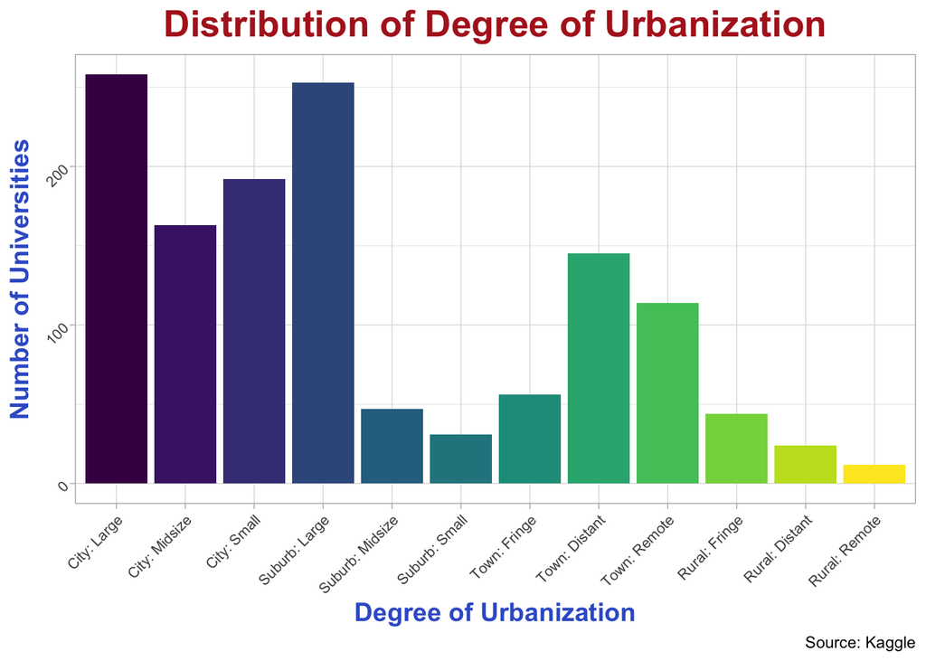

```r
ggplot(college_data, aes(x = urbanization, fill = urbanization)) +
  geom_bar() +
  labs(
    title = "Distribution of Degree of Urbanization",
    x = "Degree of Urbanization",
    y = "Number of Universities",
    caption = "Source: Kaggle"
  ) +
  our_theme +
  theme(
    axis.text = element_text(angle = 45, hjust = 1, size = 8),
    legend.position = "none"
  )
```

This graph shows the marginal distribution of degree of urbanization. It shows count in the y-axis and degree of urbanization in the x-axis. The category with the highest number of universities is Large City & the category with the smallest is Rural Remote.

#### Region

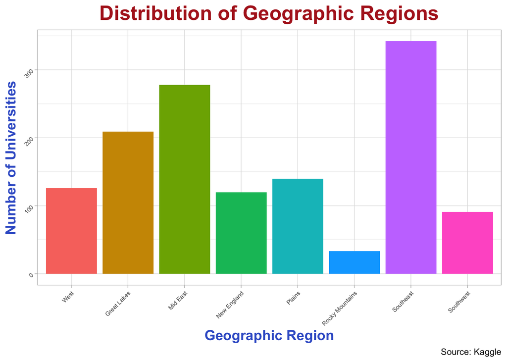

```r
ggplot(college_data, aes(x = region, fill = region)) +
  geom_bar() +
  labs(
    title = "Distribution of Geographic Regions",
    x = "Geographic Region",
    y = "Number of Universities",
    caption = "Source: Kaggle"
  ) +
  our_theme +
  theme(
    axis.text = element_text(angle = 45, hjust = 1, size = 6),
    legend.position = "none"
  )
```

This graph shows the marginal distribution of geographic region. It shows count in the y-axis and geogrpahic region in the x-axis. The region with the highest number of universities is the Southeast & the region with the smallest is the Rocky Mountains.

#### Control

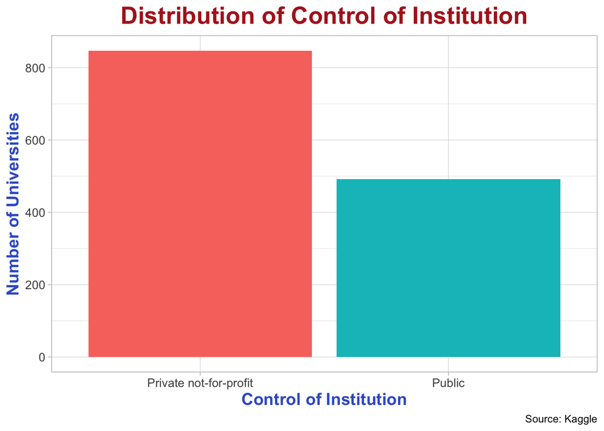

```r
ggplot(college_data, aes(x = control, fill = control)) +
  geom_bar() +
  labs(
    title = "Distribution of Control of Institution",
    x = "Control of Institution",
    y = "Number of Universities",
    caption = "Source: Kaggle"
  ) +
  our_theme +
  theme(
    axis.text = element_text(size = 10),
    legend.position = "none"
  )
```

### Continuous Variables:

#### Endowment:

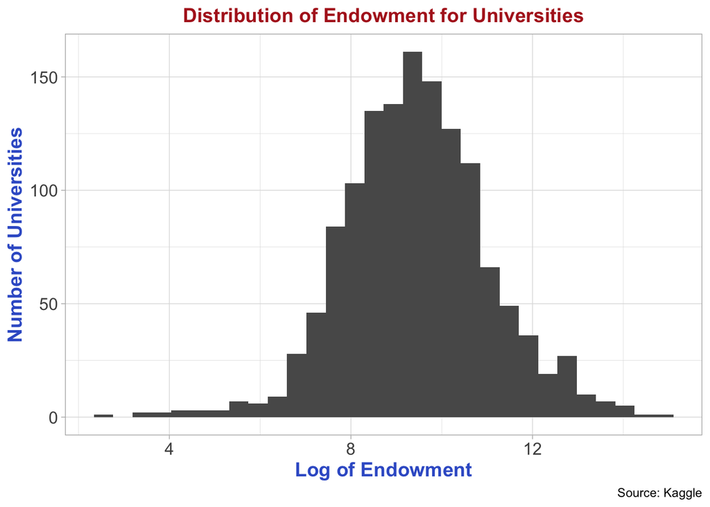

```r
ggplot(college_data, aes(x = log(endowment))) +
  geom_histogram() +
  labs(
    title = "Distribution of Endowment for Universities",
    x = "Log of Endowment",
    y = "Number of Universities",
    caption = "Source: Kaggle"
  ) +
  our_theme +
  theme(plot.title = element_text(size = 14))
```

This graph shows the marginal distribution of log(endowment). It shows count in the y-axis and log of endowment in the x-axis. The log transformation was necessary to not have the date be two skewed towards high outliers.

#### Acceptance Rate:

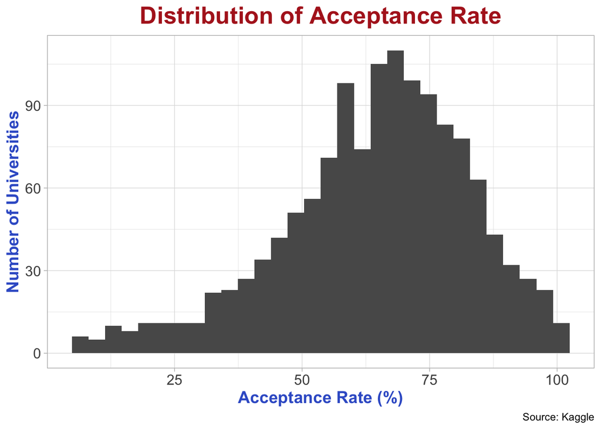

```r
ggplot(college_data, aes(x = acceptance_rate)) +
  geom_histogram() +
  labs(
    title = "Distribution of Acceptance Rate",
    x = "Acceptance Rate (%)",
    y = "Number of Universities",
    caption = "Source: Kaggle"
  ) +
  our_theme
```

This graph shows the marginal distribution of acceptance rate (%). It shows count in the y-axis and acceptance rate (%) in the x-axis. The bin with the largest number of universities has an acceptance rate of about 70%.

#### 5Y Graduation Rate:

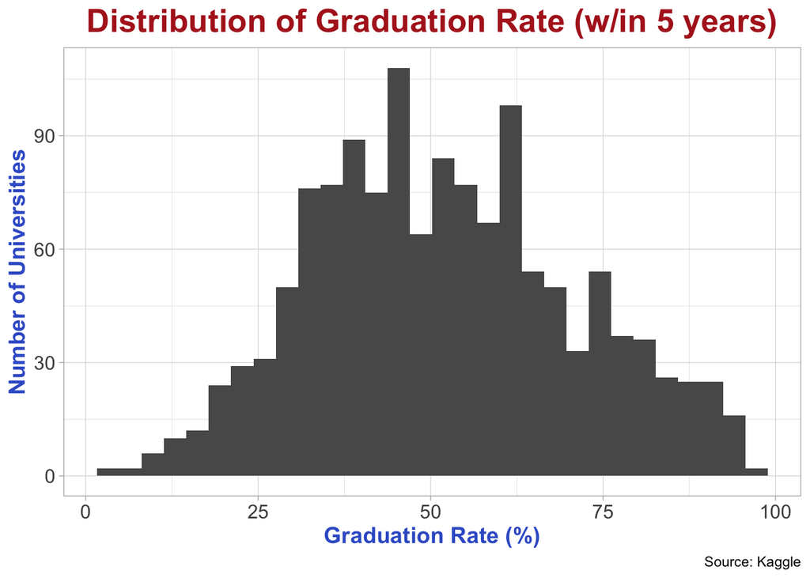

```r
ggplot(college_data, aes(x = grad_rate)) +
  geom_histogram() +
  labs(
    title = "Distribution of Graduation Rate (w/in 5 years)",
    x = "Graduation Rate (%)",
    y = "Number of Universities",
    caption = "Source: Kaggle"
  ) +
  our_theme
```

This graph shows the marginal distribution of graduation rate (%). It shows count in the y-axis and graduation rate (%) in the x-axis. The bin with the largest number of universities has a graduation rate of about 45%.

# Methods

### Acceptance Rate By Graduation Rate

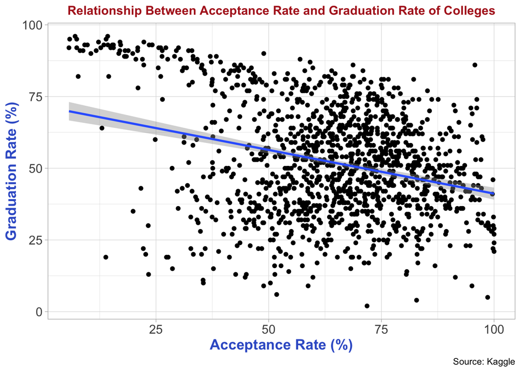

```r
ggplot(college_data, aes(x = acceptance_rate, y = grad_rate)) + geom_point() + labs(title = "Relationship Between Acceptance Rate and Graduation Rate of Colleges", x = "Acceptance Rate (%)", y = "Graduation Rate (%)", caption = "Source: Kaggle") + geom_smooth(method = "lm", se=TRUE, level = 0.95) + our_theme +
  theme(plot.title = element_text(size = 12))
```

From the scatter plot and the linear regression line we can see that there is a weak but negative correlation between the acceptance rate and the graduation rate of colleges. This means that in general, colleges with lower acceptance rates tend to have higher graduation rates; conversely, colleges with higher acceptance rates tend to have lower acceptance rates. Furthermore, the relationship seems to be relatively weak, as a lot of the data points in the scatter plots are far away from the regression line. For further analysis, we can try to include another variable that might split the colleges by region, and find subsequent regression lines for the different regions to see whether the region of the college affects the relationship between acceptance rate and the graduation rate. However, this extra variable does not have to be fixed by region; other variables such as urbanization and control (public vs. private) could be applied as well.

### Urbanization by Public/Private

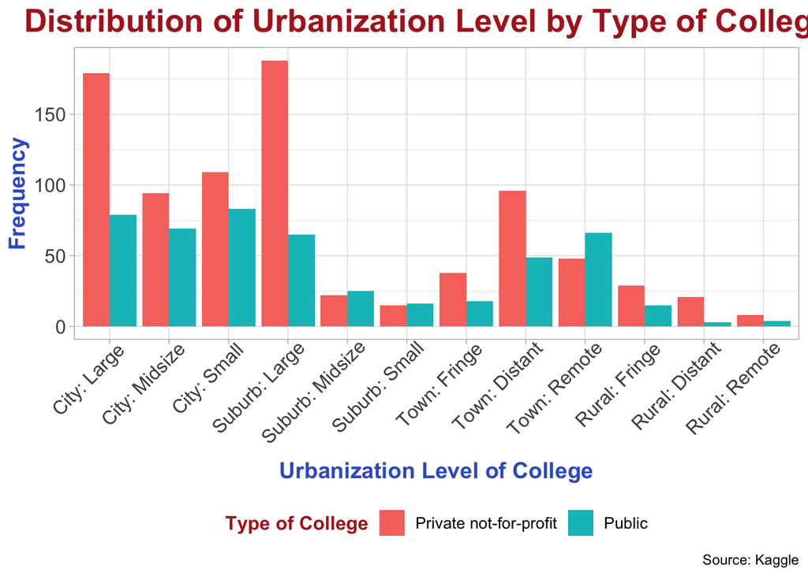

```r
ggplot(college_data, aes(x = urbanization, fill = control)) + geom_bar(position = "dodge") + labs(title = "Distribution of Urbanization Level by Type of Colleges", x = "Urbanization Level of College", y = "Frequency", fill = "Type of College", caption = "Source: Kaggle") + our_theme +   theme(axis.text.x = element_text(angle=45, hjust = .9))
```

From the bar graphs we can determine quite a few things. First, it seems like there are more private colleges than public colleges in the dataset. Second, the levels of urbanization where there are a lot more private colleges than public ones lie in large cities and large suburbs. Third, the levels of urbanization where public colleges are more than private colleges are either in remote towns or small/midsize suburbs. These are interesting findings because it seems like there are more private colleges in areas with a large concentration of people, but in small/mid-size areas some levels of urbanization clearly side with the public colleges, while others show a clear advantage in the number of private colleges. An intriguing future step would be to compare population density with the distribution of public vs. private colleges.

### Graduation Rate by Urbanization, faceted by Control

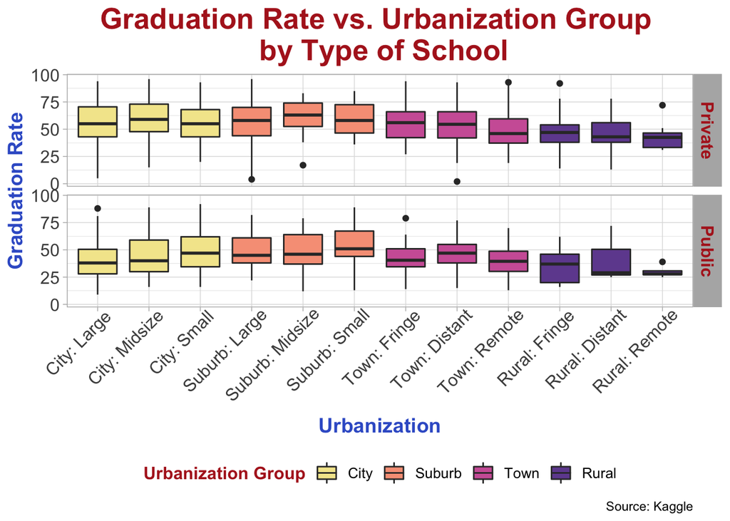

```r
con.labs <- c("Private", "Public")
names(con.labs) <- c("Private not-for-profit", "Public")

ggplot(college_data, aes(x = urbanization, y = grad_rate, fill = urbanization_group)) +
  geom_boxplot() +
  facet_grid(control~., labeller = labeller(control = con.labs)) +
  scale_fill_discrete_sequential(palette = "Sunset") +
  our_theme +
  labs(x = "Urbanization",
       y = "Graduation Rate",
       fill = "Urbanization Group",
       title = "Graduation Rate vs. Urbanization Group \n by Type of School",
       caption = "Source: Kaggle") +
  theme(axis.text.x = element_text(angle=45, hjust = .9))
```

```r
anova(lm(college_data$grad_rate ~ college_data$urbanization + college_data$control))
private_grad <- college_data$grad_rate[which(college_data$control == "Private not-for-profit")]
public_grad <- college_data$grad_rate[which(college_data$control == "Public")]

t.test(private_grad, public_grad)
```

[output not shown]

From the boxplot, we see that private schools, on average, have a higher graduation rate than public schools. We also see that schools in cities and suburbs have similar medians and variability in graduation rate, but that the median graduation rate is lower in schools in rural regions. With the exception of the public schools in the `rural: fringe` degree of urbanization, it appears that rural schools have less variability in their graduation rate.

### Control of School by Region

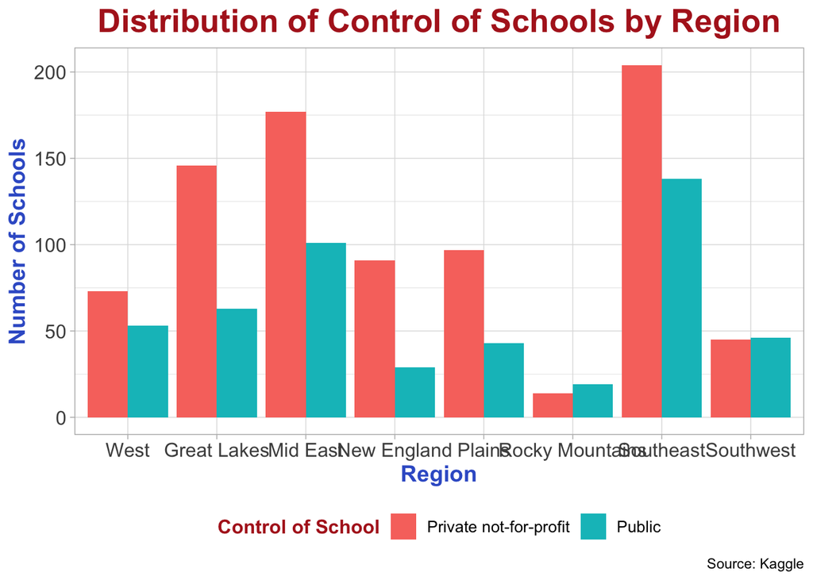

```r
ggplot(college_data, aes(x = region, fill = control)) +
  geom_bar(position = 'dodge') +
  labs(title = "Distribution of Control of Schools by Region",
       x = "Region", y = "Number of Schools", fill = "Control of School",
       caption = "Source: Kaggle") +
  our_theme
```

### Control of School by Region

```r
control_region <- college_data %>%
  group_by(region, control) %>%
  summarise(count = n())

state_region <- state_region %>%
  left_join(control_region, by = c("region" = "region"))

state_data <- state_data %>%
  left_join(state_region, by = c("state.abb" = "State")) %>%
  drop_na(control)
```

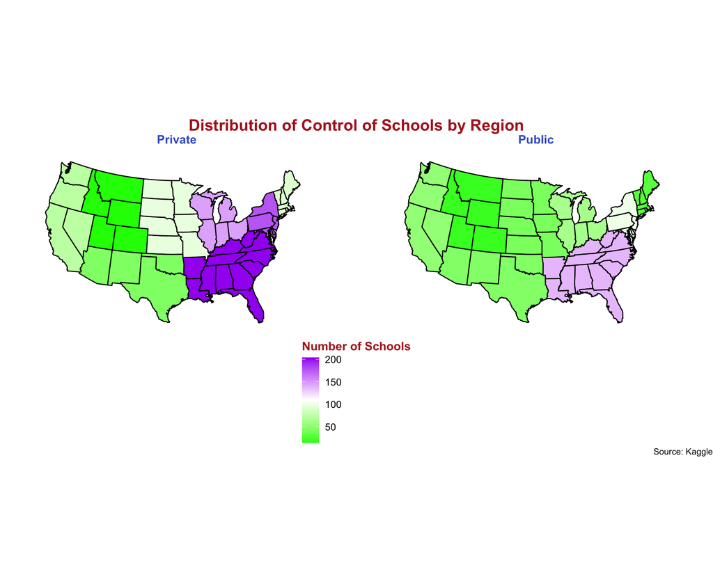

```r
ggplot(state_data) +
  geom_polygon(aes(x = long, y = lat, group = group, fill = count),
               color = "black") +
  scale_fill_gradient2(low = "green", mid = "white", high = "purple", midpoint = 110) +
  theme_void() +
  coord_map("polyconic") +
  facet_wrap(~control, labeller = labeller(control = con.labs)) +
  labs(title = "Distribution of Control of Schools by Region",
        fill = "Number of Schools",
       caption = "Source: Kaggle") +
  theme_void() +
  theme(
    plot.title = element_text(hjust = 0.5, size = 16, color = "firebrick", face = "bold"),
    axis.title = element_blank(),
    axis.text = element_blank(),
    legend.title = element_text(size = 12, color = "firebrick", face = "bold"),
    legend.text = element_text(size = 10),
    legend.position = "bottom",
    legend.direction = "vertical",
    strip.text.x = element_text(size = 12, color = "royalblue3", face = "bold")
    )
```

### Endowment vs Grad rate

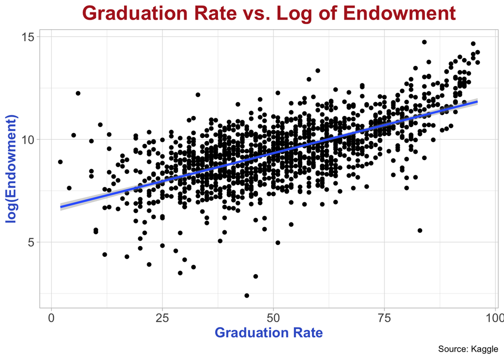

```r
ggplot(college_data, aes(x = grad_rate, y = log(endowment))) +
  geom_point() +
  geom_smooth(method = lm, se = TRUE, level = 0.95) +
  labs(title = "Graduation Rate vs. Log of Endowment",
       x = "Graduation Rate", y = "log(Endowment)",
       caption = "Source: Kaggle") +
  our_theme
```

First, since the endowment had significantly larger units, we transformed the data into logarithm of endowment, and plotted a scatter plot with graduation rate on the x-axis and logarithm of endowment on the y-axis. The scatter plot shows an overall positive relationship between the two variables. This is more apparent with the linear regression line. Since the 95% error bound of the regression line doesn’t include slope of 0, we needed further testing to confirm that there indeed is a positive relationship.

### Endowment by region, faceted by public/private

```r
s_region <- s_region %>%
  mutate(region = tolower(region))

us_data <- map_data("state") %>%
  filter(region != "district of columbia")

lookup <- data.frame(
  state_abbrev = state.abb,
  state_full = tolower(state.name)
)

us_data <- us_data %>%
  left_join(lookup, by = c("region" = "state_full"))

us_data <- us_data %>%
  left_join(s_region, by = c("state_abbrev" = "State"))

us_data <- us_data %>%
  mutate(usregion = region.y)

c_data <- college_data %>%
  dplyr::select(name, endowment, region, control)

c_data <- c_data %>%
  mutate(region = tolower(region))

endowment_by_region_by_control <- c_data %>%
  group_by(control, region) %>%
  summarise(Count = n(),
    mean_endowment = mean(endowment, na.rm = T))

us_data <- us_data %>%
  left_join(endowment_by_region_by_control, by = c("region.y" = "region"))
```

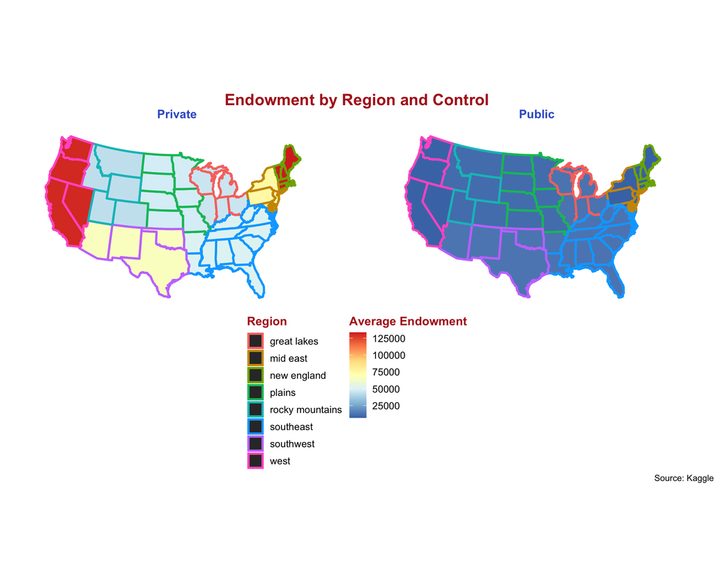

```r
ggplot(us_data) +
  geom_polygon(aes(x = long, y = lat, group = group, color = usregion, fill = mean_endowment), size = 1.05) +
  scale_fill_distiller(type = "div", limits = c(min(us_data$mean_endowment), max(us_data$mean_endowment)), palette = "RdYlBu", na.value = "grey50") +
  facet_wrap(control ~ ., labeller = labeller(control = con.labs)) +
  coord_map("polyconic") +
  labs(
    title = "Endowment by Region and Control",
    color = "Region",
    fill = "Average Endowment",
    caption = "Source: Kaggle"
  ) +
  theme_void() +
  theme(
    plot.title = element_text(hjust = 0.5, size = 16, color = "firebrick", face = "bold"),
    axis.title = element_blank(),
    axis.text = element_blank(),
    legend.title = element_text(size = 12, color = "firebrick", face = "bold"),
    legend.text = element_text(size = 10),
    legend.position = "bottom",
    legend.direction = "vertical",
    strip.text.x = element_text(size = 12, color = "royalblue3", face = "bold")
    )
```

# Conclusion

## Results

Most of the findings were in line with our initial hypothesis, while there were a few notable exceptions. While we thought the overall number of schools wouldn’t depend on the region, we found that the Southeast region had the most number of schools regardless of whether it is public or private. Also, we found that the endowment distribution is very different between private and public schools which was contrasting from our initial thoughts.

## Discussion

While this dataset was very useful and effective in investigating our questions, there were some minor limitations of our data/analysis. First, the data isn’t very recent (2013-2014), though it does seem as if it is still being updated every year but that there is a lag in the data. Next, some colleges had missing information, which we noted and summarized above but did not utilize in our methods. Lastly, the dataset does not include Private for-profit Institutions, a whole additional segment of the education landscape which could shed light on some interesting findings.